# Reproducible Preprocessing of 16.7 Million GISAID SARS-CoV-2 Spike Protein Sequences in R

Vadim Tyuryaev, Jane Heffernan, Hanna Jankowski

2026-04-27

# 1 Overview

This document records the complete preprocessing pipeline applied to GISAID SARS-CoV-2 Spike protein sequences downloaded in April 2024. The goal is to produce a clean, integer-encoded amino acid data matrix in the format required by `partition_time_windows()` and the broader `ViralEntropR` detection pipeline.

The pipeline proceeds in six stages:

1. Load the GISAID fasta file and the reference sequence.
2. Extract and validate collection dates and country annotations.
3. Filter to United States sequences within a biologically justified date window and sequence length range.
4. Remove sequences containing ambiguous amino acid residues.
5. Align short sequences (width < 1273 aa) against the reference using ClustalOmega; merge with full-length sequences.
6. Encode the aligned matrix and assemble the final data frame.

Elapsed times are recorded at each stage using `tictoc` to provide an honest account of the computational cost of pre-processing at this scale.

> **Computational note.** Estimated peak RAM consumption is approximately 40 GB. Every effort has been made to release large intermediate objects explicitly via `rm()` and `gc()` to minimise memory pressure throughout the pipeline. The dominant wall-clock cost is the alignment step itself, which takes approximately 6 hours on a Linux server.

# 2 Prerequisites

## 2.1 Data download

The GISAID Spike protein dataset (`spikeprot0410.fasta`) must be downloaded manually before running this pipeline. GISAID data access requires registration and agreement to the GISAID Data Access Agreement.

1. Visit the [GISAID EpiCov Database](https://www.epicov.org) and log in.
2. Navigate to **EpiCov → Downloads**.
3. Download the file named `spikeprot0410.fasta` (or the nearest equivalent release).

A reference sequence (`Ref_Seq.fasta`) corresponding to the canonical SARS-CoV-2 Spike protein [GenBank: YP_009724390.1, 1273 aa](https://www.ncbi.nlm.nih.gov/protein/1796318598) is also required.

## 2.2 Install BiocManager and relevant packages

```r
# Install BiocManager if you don't already have it
if (!require("BiocManager", quietly = TRUE))
    install.packages("BiocManager")

BiocManager::install("Biostrings")
BiocManager::install("msa")
BiocManager::install("DECIPHER")
```

## 2.3 Libraries

```r
library(Biostrings)
library(dplyr)
library(ggplot2)
library(lubridate)
library(msa)
library(tictoc)
library(zoo)
library(ViralEntropR)
```

# 3 Stage 1: Load fasta_GISAID Data

The raw GISAID file contains sequences from all countries with dates spanning the full pandemic period. We load the file and record the total sequence count before any filtering.

```r
tic("Stage 1: Load fasta_GISAID")
fasta_GISAID   <- readAAStringSet("spikeprot0410.fasta", format = "fasta")
Ref_Seq <- readAAStringSet("Ref_Seq.fasta")
toc()
```

```
#> Stage 1: Load fasta_GISAID: 147.341 sec elapsed
```

```r
n_seq_orig <- length(fasta_GISAID)
sprintf("Raw sequence count: %d", n_seq_orig)
```

```
#> [1] "Raw sequence count: 16695885"
```

# 4 Stage 2: Date and Country Extraction

## 4.1 Extract collection dates — first pass

GISAID sequence headers follow the pipe-delimited format:

```
Spike|hCoV-19/USA/OH-PLMI-HCFL5-xxxxxx/2021|2021-xx-xx|EPI_ISL_xxxxxxx|Original|hCoV-19^^Ohio|Human|
```

`extract_fasta_dates()` parses the date field using the `yyyy-mm-dd` pattern. Dates where the day component is recorded as `00` (a common GISAID convention indicating unknown collection day) are corrected to `01` and stored in `$corrected_dates`. A leading zero for month or day is permitted.

```r
tic("Stage 2a: Extract dates (pass 1)")
dates_result <- extract_fasta_dates(fasta_GISAID, option = 1)
toc()
```

```
#> Stage 2a: Extract dates (pass 1): 176.212 sec elapsed
```

```r
dates_result$message
```

```
#> [1] "There are date strings that have not been recognized"
```

```r
n_miss <- length(dates_result$missing_id)
sprintf("Sequences with missing or unparseable dates: %d", n_miss)
```

```
#> [1] "Sequences with missing or unparseable dates: 182178"
```

```r
# Inspect a sample of headers with missing dates to confirm they are
# year-only records (e.g. "2021") rather than structurally malformed entries
sample(fasta_GISAID[dates_result$missing_id], 1000) %>% names() %>% head(10)
```

```
#>  [1] "Spike|hCoV-19/England/PHEC-2FAAAF/2021|2021-00-00|EPI_ISL_2738868|Original|hCoV-19^^England|Human|Respiratory Virus Unit|COVID-19 Genomics UK (COG-UK) Consortium|Lackenby|United Kingdom"
#>  [2] "Spike|hCoV-19/USA/CT-YNH-1344/2022|2022-00-00|EPI_ISL_15318221|Original|hCoV-19^^Connecticut|Human|YNHH Clinical Virology Laboratory|YNHH Department of Laboratory Medicine|Durant|USA"
#>  [3] "Spike|hCoV-19/India/KL-2459-KNR-3344/2022|2022-00-00|EPI_ISL_15614050|Original|hCoV-19^^Kerala|Human|LMMD|LMMD-RGCB-INSACOG|Nair|India"
#>  [4] "Spike|hCoV-19/USA/SD-INBRE-0096/2021|2021-00-00|EPI_ISL_15035558|Original|hCoV-19^^South Dakota|Human|SD-INBRE|BicBioEng Lab|Gnimpieba Zohim|USA"
#>  [5] "Spike|hCoV-19/India/KL-3894-KZD-2425/2022|2022-00-00|EPI_ISL_15824891|Original|hCoV-19^^Kerala|Human|Laboratory Medicine & Molecular Diagnostics|Laboratory Medicine & Molecular Diagnostics|Nair|India"
#>  [6] "Spike|hCoV-19/USA/CT-YNH-1961/2022|2022-00-00|EPI_ISL_15825990|Original|hCoV-19^^Connecticut|Human|YNHH Clinical Virology Laboratory|YNHH Department of Laboratory Medicine|Durant|USA"
#>  [7] "Spike|hCoV-19/England/NORT-1B64075/2020|2020-00-00|EPI_ISL_839514|Original|hCoV-19^^England|Human|Northumbria University / South Tees Hospitals NHS Foundation Trust / North Cumbria Integrated Care NHS Foundation Trust / North Tees and Hartlepool NHS Foundation"
#>  [8] "Spike|hCoV-19/England/PHEC-YYBYBAQE/2021|2021-00-00|EPI_ISL_3777555|Original|hCoV-19^^England|Human|Respiratory Virus Unit|COVID-19 Genomics UK (COG-UK) Consortium|Lackenby|United Kingdom"
#>  [9] "Spike|hCoV-19/England/PHEC-3Y0A7Y59/2021|2021-00-00|EPI_ISL_8449323|Original|hCoV-19^^England|Human|Respiratory Virus Unit|COVID-19 Genomics UK (COG-UK) Consortium|Lackenby|United Kingdom"
#> [10] "Spike|hCoV-19/England/ARCH-002981A1/2022|2022-00-00|EPI_ISL_11739046|Original|hCoV-19^^England|Human|Quadram Institute Bioscience|COVID-19 Genomics UK (COG-UK) Consortium|Alikhan|United Kingdom"
```

Sequences lacking complete month and day collection data (e.g., ‘2021-00-00’) are removed prior to downstream analysis. Reliable monthly resolution is necessary for downstream temporal partitioning.

```r
fasta_GISAID <- fasta_GISAID[-dates_result$missing_id]

n_seq_filtered_1 <- length(fasta_GISAID)

# Arithmetic sanity check: removed exactly n_miss sequences
stopifnot(n_miss == n_seq_orig - n_seq_filtered_1)
sprintf("Sequences remaining after date filtering: %d", n_seq_filtered_1)
```

```
#> [1] "Sequences remaining after date filtering: 16513707"
```

## 4.2 Extract country annotations

```r
tic("Stage 2b: Extract countries")
countries_result <- extract_fasta_countries(fasta_GISAID, position = 3)
toc()
```

```
#> Stage 2b: Extract countries: 39.544 sec elapsed
```

```r
countries_result$message
```

```
#> [1] "All countries have been extracted"
```

```r
countries_result$missing_id        # expect NA (no missing country fields)
```

```
#> [1] NA
```

```r
sum(is.na(countries_result$countries))             # 0 NAs
```

```
#> [1] 0
```

```r
sum(countries_result$countries == "USA")           # 5,081,078 labelled "USA"
```

```
#> [1] 5081078
```

```r
# Country distribution — reveals other US labels: "United States", "US"
countries_result$countries %>%
  table() %>%
  sort(decreasing = TRUE)%>%head(50)
```

```
#> .
#>              USA          England          Germany           France
#>          5081078          2377165           946875           669251
#>          Denmark            Japan           Canada         Scotland
#>           659714           658356           626019           380696
#>            India           Sweden          Austria            Spain
#>           278506           278504           266840           261761
#>            Wales           Brazil        Australia            Italy
#>           252644           250010           229903           197317
#>      South Korea          Belgium      Netherlands      Switzerland
#>           188636           182882           176189           166087
#>           Israel          Ireland           Turkey           Poland
#>           158641           112086           103340            95363
#>           Mexico         Slovenia           Russia           Norway
#>            94640            88071            85268            80114
#> Northern Ireland   Czech Republic       Luxembourg     South Africa
#>            71079            61371            59089            55594
#>             Peru        Indonesia          Finland         Portugal
#>            54704            54263            52045            49388
#>         Slovakia            Chile        Singapore          Croatia
#>            48181            48052            47168            46636
#>      New Zealand         Malaysia         Thailand        Lithuania
#>            45326            44790            44430            43414
#>           Greece         Colombia      Philippines           Latvia
#>            39291            30583            29627            27618
#>        Argentina          Iceland
#>            24868            23695
```

## 4.3 Re-extract dates and perform thorough validation

After country extraction, dates are re-extracted from the current fasta_GISAID object (which had missing-date sequences removed) to produce two fully aligned metadata vectors. Four independent NA checks confirm that the corrected date vector is complete and that the `dd=00` correction propagated correctly.

```r
tic("Stage 2c: Re-extract dates and validate")
dates_result <- extract_fasta_dates(fasta_GISAID, option = 1)
toc()
```

```
#> Stage 2c: Re-extract dates and validate: 177.213 sec elapsed
```

```r
dates_result$message
```

```
#> [1] "All date strings have been successfully extracted"
```

```r
# Four-way NA check: raw strings, corrected strings, raw dates, corrected dates
sum(is.na(dates_result$raw_date_strings))       # should be 0
```

```
#> [1] 0
```

```r
sum(is.na(dates_result$corrected_date_strings)) # should be 0
```

```
#> [1] 0
```

```r
sum(is.na(dates_result$raw_dates))              # non-zero: dd=00 entries
```

```
#> [1] 228375
```

```r
sum(is.na(dates_result$corrected_dates))        # should be 0 — confirmed
```

```
#> [1] 0
```

```r
# Inspect headers where raw dates are NA (dd=00) to confirm the
# corrected_dates field handles them appropriately
# Set the seed using the date format YYYYMMDD (April 6, 1928)
set.seed(19280406)
sample(fasta_GISAID[which(is.na(dates_result$raw_dates))], 1000) %>% names() %>% head(5)
```

```
#> [1] "Spike|hCoV-19/Thailand/NIC_PTE_SEQ5828/2022|2022-01-00|EPI_ISL_10744441|Original|hCoV-19^^Pathum Thani|Human|Lamlukka Hospital|National Institute of Health|Thongpramul|Thailand"
#> [2] "Spike|hCoV-19/France/un-IHU-014185/2020|2020-11-00|EPI_ISL_17746286|Original|hCoV-19^^France|Human|Institut Hospitalo-Universitaire Mediterranee Infection|Institut Hospitalo-Universitaire Mediterranee Infection|Submitter|France"
#> [3] "Spike|hCoV-19/India/DL-IGIB1120213504806TV/2021|2021-12-00|EPI_ISL_8881183|Original|hCoV-19^^Delhi|Human|National Centre for Disease control (NCDC)|NCDC/CSIR-IGIB/INSACOG|Pandey|India"
#> [4] "Spike|hCoV-19/USA/FL-Path-Saliva-1021/2021|2021-04-00|EPI_ISL_2991349|Original|hCoV-19^^Florida|Human|University of Florida Health Pathology Laboratories|Salemi Lab|Riva|USA"
#> [5] "Spike|hCoV-19/Canada/BC-6399/2020|2020-10-00|EPI_ISL_751849|Original|hCoV-19^^British Columbia|Human|BCCDC Public Health Laboratory|BCCDC Public Health Laboratory|Prystajecky|Canada"
```

```r
# dd is labelled 00 --> corrected_dates replaces 00 with 01
set.seed(19280406)
sample(dates_result$corrected_date_strings[which(is.na(dates_result$raw_dates))], 1000)%>% head(5)
```

```
#> [1] "2022-01-01" "2020-11-01" "2021-12-01" "2021-04-01" "2020-10-01"
```

```r
sprintf("Date range: %s  to  %s",
        min(dates_result$corrected_dates),
        max(dates_result$corrected_dates))
```

```
#> [1] "Date range: 2010-12-06  to  2024-04-02"
```

```r
# Verify metadata vectors are aligned
stopifnot(
  length(fasta_GISAID) == length(dates_result$corrected_dates),
  length(fasta_GISAID) == length(countries_result$countries)
)
```

## 4.4 Date range filter — remove pre-pandemic and out-of-window sequences

The SARS-CoV-2 pandemic began in late 2019. Sequences dated before `2019-12-01` cannot be genuine SARS-CoV-2 Spike protein records. Similarly, sequences beyond the date of data base download (`2024-04-10`) are out of scope. Both are identified and removed.

```r
start_date <- as.Date("2019-12-01")
end_date   <- as.Date("2024-04-10")

# Identify out-of-window sequences and inspect their headers
out_of_window_idx <- which(
  dates_result$corrected_dates < start_date |
  dates_result$corrected_dates > end_date
)

sprintf("Sequences outside the analysis window: %d", length(out_of_window_idx))
```

```
#> [1] "Sequences outside the analysis window: 9"
```

```r
# Inspect suspicious sequence headers
if (length(out_of_window_idx) > 0) {
  cat("Sample of out-of-window sequence headers:\n")
  print(head(names(fasta_GISAID)[out_of_window_idx], 20))

  # Remove out-of-window sequences
  fasta_GISAID            <- fasta_GISAID[-out_of_window_idx]
  dates_result     <- extract_fasta_dates(fasta_GISAID, option = 1)
  countries_result <- extract_fasta_countries(fasta_GISAID, position = 3)
}
```

```
#> Sample of out-of-window sequence headers:
#> [1] "Spike|hCoV-19/bat/Yunnan/RsYN03/2019|2019-10-22|EPI_ISL_1699443|Original|hCoV-19^^Yunnan|Rhinolophus sinicus|Shandong First Medical University & Shandong Academy of Medical Sciences|Shandong First Medical University & Shandong Academy of Medical Sciences|Ji|Ch"
#> [2] "Spike|hCoV-19/bat/Yunnan/PrC31/2018|2018-08-00|EPI_ISL_1098866|Original|hCoV-19^^Yunnan|Rhinolophus bat|Yunnan Tropical and Subtropical Animal Viral Disease Laboratory|Diarrhea department|Li|China"
#> [3] "Spike|hCoV-19/pangolin/China/MP789/2019|2019-03-19|EPI_ISL_412860|unknown|hCoV-19^^China|Manis javanica|SCSFRI|SCSFRI|Submitter|China"
#> [4] "Spike|hCoV-19/bat/Yunnan/RaTG13/2013|2013-07-24|EPI_ISL_402131|Original|hCoV-19^^Yunnan|Rhinolophus affinis|Wuhan Institute of Virology|Wuhan Institute of Virology|Shi|China"
#> [5] "Spike|hCoV-19/bat/Yunnan/RmYN01/2019|2019-06-25|EPI_ISL_412976|Original|hCoV-19^^Yunnan|Rhinolophus malayanus|Shandong First Medical University & Shandong Academy of Medical Sciences|Institute of Microbiology|Bi|China"
#> [6] "Spike|hCoV-19/bat/Yunnan/RmYN02/2019|2019-06-25|EPI_ISL_412977|Original|hCoV-19^^Yunnan|Rhinolophus malayanus|Shandong First Medical University & Shandong Academy of Medical Sciences|Institute of Microbiology|Bi|China"
#> [7] "Spike|hCoV-19/bat/Cambodia/RShSTT182/2010|2010-12-06|EPI_ISL_852604|Original|hCoV-19^^Steung Treng|Rhinolophus shameli|Virology Unit|G5 Evolutionary Genomics of RNA viruses|Simon-Loriere|Cambodia"
#> [8] "Spike|hCoV-19/bat/Cambodia/RShSTT200/2010|2010-12-06|EPI_ISL_852605|Original|hCoV-19^^Steung Treng|Rhinolophus shameli|Virology Unit|G5 Evolutionary Genomics of RNA viruses|Simon-Loriere|Cambodia"
#> [9] "Spike|hCoV-19/pangolin/Yunnan/MP20/2017|2017-08-29|EPI_ISL_610156|Original|hCoV-19^^Yunnan|Manis pentadactyla|State Key Laboratory of Genetic Resources and Evolution|State Key Laboratory of Genetic Resources and Evolution|Peng|China"
```

```r
rm(out_of_window_idx)
gc()
```

```
#>              used    (Mb) gc trigger    (Mb)   max used    (Mb)
#> Ncells   19905279  1063.1   66150924  3532.9   53470829  2855.7
#> Vcells 3180806267 24267.7 5367578220 40951.4 4397794705 33552.6
```

```r
sprintf("Sequences remaining after date range filter: %d", length(fasta_GISAID))
```

```
#> [1] "Sequences remaining after date range filter: 16513698"
```

## 4.5 Collection date distribution

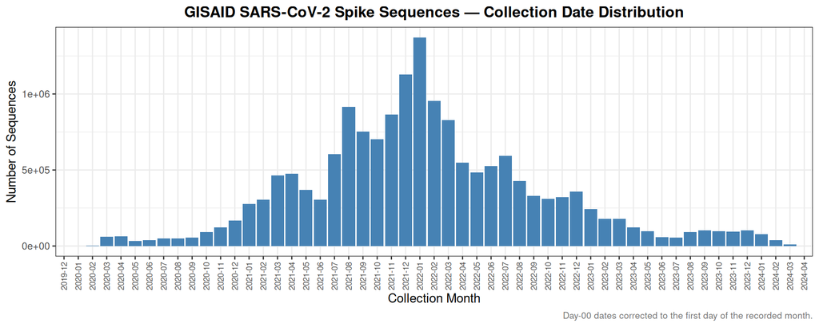

```r
date_df <- data.frame(
  Date = as.Date(dates_result$corrected_dates)
) %>%
  mutate(YearMonth = format(Date, "%Y-%m"))

p=ggplot(date_df, aes(x = YearMonth)) +
  geom_bar(stat = "count", fill = "steelblue") +
  theme_bw() +
  theme(
    axis.text.x  = element_text(angle = 90, hjust = 1, vjust = 0.5, size = 7),
    plot.title   = element_text(hjust = 0.5, face = "bold"),
    plot.caption = element_text(hjust = 1, colour = "grey45", size = 8)
  ) +
  labs(
    x       = "Collection Month",
    y       = "Number of Sequences",
    title   = "GISAID SARS-CoV-2 Spike Sequences — Collection Date Distribution",
    caption = "Day-00 dates corrected to the first day of the recorded month."
  )

print(p)
```

```r
ggsave(filename = "GISAID_Collection_Distribution_Clean_All_Sequences.png",
       plot = p,
       width = 10,     # Width of the image in inches
       height = 6,     # Height of the image in inches
       dpi = 300,      # Resolution (300 is standard for publications)
       bg = "white")   # Ensures the background is white, not transparent

rm(date_df,p)
gc()
```

```
#>              used    (Mb) gc trigger    (Mb)   max used    (Mb)
#> Ncells   20169038  1077.2   66150924  3532.9   53470829  2855.7
#> Vcells 3197805123 24397.4 5367578220 40951.4 5077222045 38736.2
```

# 5 Stage 3: Geographic and Length Filtering

## 5.1 Filter to United States sequences

Analyses are restricted to United States sequences to minimise confounding from inter-country sampling heterogeneity and surveillance intensity differences. Analysis above reveals three country labels for the United States: `"USA"`, `"United States"`, and `"US"`. Combined, these account for 5,081,317 sequences (5,081,078 + 121 + 118).

```r
tic("Stage 3a: Filter to USA")
us_idx <- which(countries_result$countries %in% c("USA", "United States", "US"))
fasta_GISAID  <- fasta_GISAID[us_idx]
toc()
```

```
#> Stage 3a: Filter to USA: 0.485 sec elapsed
```

```r
rm(us_idx)
gc()
```

```
#>              used    (Mb) gc trigger    (Mb)   max used    (Mb)
#> Ncells    8728775   466.2   52920740  2826.3   53470829  2855.7
#> Vcells 2874508028 21930.8 5367578220 40951.4 5077222045 38736.2
```

```r
# Re-align metadata
dates_result     <- extract_fasta_dates(fasta_GISAID, option = 1)
countries_result <- extract_fasta_countries(fasta_GISAID, position = 3)

sprintf("US sequences: %d", length(fasta_GISAID))
```

```
#> [1] "US sequences: 5081317"
```

## 5.2 Filter by sequence length

The canonical SARS-CoV-2 spike protein (`YP_009724390.1`) is 1273 amino acids in length. GISAID sequences of width 1274 include a terminal stop codon (*), which is removed during preprocessing. Sequences shorter than 1268 amino acids typically reflect large deletions relative to the reference and disrupt the positional correspondence required by the fixed-width representation used in this pipeline, while sequences longer than 1274 amino acids contain insertions relative to the reference. Both cases are excluded to preserve consistent site-wise comparability across sequences.

```r
tic("Stage 3b: Filter by sequence length")
fasta_GISAID <- fasta_GISAID[width(fasta_GISAID) >= 1268L & width(fasta_GISAID) <= 1274L]
toc()
```

```
#> Stage 3b: Filter by sequence length: 0.358 sec elapsed
```

```r
# Re-align metadata
dates_result     <- extract_fasta_dates(fasta_GISAID, option = 1)
countries_result <- extract_fasta_countries(fasta_GISAID, position = 3)

# Width distribution after length filter
width(fasta_GISAID) %>% table() %>% sort(decreasing = TRUE)
```

```
#> .
#>    1271    1272    1269    1274    1270    1268    1273
#> 1462478 1410002  822200  817689  365442   88641   40133
```

## 5.3 Remove sequences containing ambiguous residues

Sequences containing ambiguous amino acid codes — B (Asp/Asn), J (Leu/Ile), X (unknown), and Z (Glu/Gln) — are removed prior to analysis. These symbols encode uncertainty rather than distinct residues and, if treated as separate categories, can bias frequency-based measures such as Shannon entropy by inflating the effective alphabet size. This introduces noise into downstream distance calculations and clustering, potentially obscuring true patterns of sequence variability.

```r
tic("Stage 3c: Remove ambiguous residues")
keep_idx <- !grepl("X|B|Z|J", as.character(fasta_GISAID), ignore.case = TRUE)
fasta_GISAID    <- fasta_GISAID[keep_idx]
toc()
```

```
#> Stage 3c: Remove ambiguous residues: 136.127 sec elapsed
```

```r
rm(keep_idx)
gc()
```

```
#>              used    (Mb) gc trigger    (Mb)   max used    (Mb)
#> Ncells    6756394   360.9   42336592  2261.1   53470829  2855.7
#> Vcells 2781495390 21221.2 5367578220 40951.4 5077222045 38736.2
```

```r
# Re-align metadata
dates_result     <- extract_fasta_dates(fasta_GISAID, option = 1)
countries_result <- extract_fasta_countries(fasta_GISAID, position = 3)

# Width distribution after ambiguous residue removal
width(fasta_GISAID) %>% table() %>% sort(decreasing = TRUE)
```

```
#> .
#>   1272   1271   1269   1274   1270   1268   1273
#> 936515 910893 586565 371821 239891  48733  15156
```

```r
saveRDS(fasta_GISAID,            "seqs_US_filtered_unaligned.rds")
saveRDS(dates_result,     "metadata_dates_US_filtered_unaligned.rds")
saveRDS(countries_result, "metadata_countries_US_filtered_unaligned.rds")
```

# 6 Stage 4: Deduplication and Stop Codon Removal

Exact duplicate sequences provide no additional information for entropy calculations and inflate computation time substantially. We deduplicate separately for sequences requiring alignment (width ≤ 1273) and sequences of canonical width (1274, including the stop codon).

```r
tic("Stage 4a: Split and deduplicate")
fasta_GISAID_short   <- unique(fasta_GISAID[width(fasta_GISAID) != 1274L])
fasta_GISAID_regular <- unique(fasta_GISAID[width(fasta_GISAID) == 1274L])
toc()
```

```
#> Stage 4a: Split and deduplicate: 6.7 sec elapsed
```

```r
rm(fasta_GISAID)
gc()
```

```
#>              used    (Mb) gc trigger    (Mb)   max used    (Mb)
#> Ncells    3789071   202.4   33869274  1808.9   53470829  2855.7
#> Vcells 2690920945 20530.1 5367578220 40951.4 5077222045 38736.2
```

```r
sprintf("Unique short sequences (width 1268-1273): %d", length(fasta_GISAID_short))
```

```
#> [1] "Unique short sequences (width 1268-1273): 121621"
```

```r
sprintf("Unique regular sequences (width 1274):    %d", length(fasta_GISAID_regular))
```

```
#> [1] "Unique regular sequences (width 1274):    20238"
```

Terminal stop codons (*) are removed prior to alignment. While treated as valid symbols by Clustal Omega, their presence introduces non-biological variation at the C-terminus, which can lead to artificial mismatches and, in cases of inconsistent sequence lengths, may contribute to spurious gap placement at terminal positions.

The `endoapply` function is a specialized iteration method in R that applies a given function across all elements of a list-like object while returning an output of the exact same S4 class as the original input.

We utilize it in this step to ensure that removing the terminal stop codons preserves the native Bioconductor sequence class (`AAStringSet`) of the data, preventing the sequences from being unintentionally coerced into a standard R list.

```r
remove_stop_codon <- function(seq) {
  AAString(gsub("\\*", "", as.character(seq)))
}

tic("Stage 4b: Remove stop codons (short sequences)")
fasta_GISAID_short <- endoapply(fasta_GISAID_short, remove_stop_codon)
toc()
```

```
#> Stage 4b: Remove stop codons (short sequences): 73.806 sec elapsed
```

```r
tic("Stage 4c: Remove stop codons (regular sequences)")
fasta_GISAID_regular <- endoapply(fasta_GISAID_regular, remove_stop_codon)
toc()
```

```
#> Stage 4c: Remove stop codons (regular sequences): 12.194 sec elapsed
```

```r
# Confirm stop codons removed from both sets
stopifnot(!any(grepl("\\*", as.character(fasta_GISAID_short))))
stopifnot(!any(grepl("\\*", as.character(fasta_GISAID_regular))))

saveRDS(fasta_GISAID_short,   "seqs_US_GISAID_unaligned_unique_short.rds")
saveRDS(fasta_GISAID_regular, "seqs_US_GISAID_unaligned_unique_1273aa.rds")
```

# 7 Stage 5: Multiple Sequence Alignment (MSA)

## 7.1 Rationale

Sequences of width 1268–1273 carry one to five amino acid deletions relative to the reference. To assign site positions consistently across all sequences, each short sequence is aligned individually against the 1273-aa reference using Clustal Omega in pairwise mode. The reference sequence serves as an anchor for positional correspondence and is discarded from the output; only the aligned form of each query sequence is retained.

The parameter **threads = 1** is specified explicitly. For a two-sequence alignment (one query and one reference), Clustal Omega constructs a trivial guide tree and performs minimal profile alignment, resulting in a computational workload that is inherently sequential. In this setting, increasing the number of threads provides no practical performance benefit and may introduce unnecessary overhead.

## 7.2 Test run on 100 sequences

To validate the alignment logic and forecast computational requirements, a preliminary benchmark was conducted on a randomized sample of 100 sequences. This approach yields a robust empirical average of the per-sequence runtime, acknowledging that individual execution times may fluctuate depending on sequence divergence (e.g., insertion/deletion events) and dynamic hardware allocation.

```r
perform_alignment <- function(sequences, reference) {
  combined <- c(reference, sequences)
  env      <- environment()
  capture.output(suppressMessages(
    env$result <- msa(combined,
                      method  = "ClustalOmega",
                      order   = "input",
                      type    = "protein",
                      threads = 1L,
                      verbose = FALSE,
                      help    = FALSE)
  ))
  env$result@unmasked[-1L]
}

# 1. Set reproducible seed for the test sample
set.seed(19760727)

# 2. Sample 100 distinct sequences
test_seq <- sample(fasta_GISAID_short, 100L)

# 3. Split into 100 individual chunks (each containing exactly 1 sequence)
test_chunks <- split(test_seq, seq_along(test_seq))

# 4. Time the one-by-one alignment process
tic("Test: 100 individual sequence alignments")
aligned_test <- lapply(test_chunks, perform_alignment, Ref_Seq)
aligned_test <- Reduce(c, aligned_test)
timer <- toc()
```

```
#> Test: 100 individual sequence alignments: 22.172 sec elapsed
```

```r
# 5. Extract elapsed time to calculate the per-sequence average
total_test_sec <- timer$toc - timer$tic
sec_per_seq    <- total_test_sec / 100
total_seqs     <- length(fasta_GISAID_short)

est_total_seconds <- sec_per_seq * total_seqs
est_total_hours   <- est_total_seconds / 3600

# 6. Print the projection
sprintf("Empirical average per sequence: %.4f seconds", sec_per_seq)
```

```
#> [1] "Empirical average per sequence: 0.2217 seconds"
```

```r
sprintf("Estimated production time for %d sequences: %.2f hours",
            total_seqs, est_total_hours)
```

```
#> [1] "Estimated production time for 121621 sequences: 7.49 hours"
```

```r
rm(test_seq,test_chunks,aligned_test)
gc()
```

```
#>            used  (Mb) gc trigger    (Mb)   max used    (Mb)
#> Ncells  4092516 218.6   27095420  1447.1   53470829  2855.7
#> Vcells 98352459 750.4 4294062576 32761.1 5077222045 38736.2
```

## 7.3 Production alignment (~6 hours)

```r
tic("Stage 5 production: Align ~121,621 sequences")
prod_chunks  <- split(fasta_GISAID_short, seq_along(fasta_GISAID_short))
aligned_prod <- lapply(prod_chunks, perform_alignment, Ref_Seq)
aligned_prod <- Reduce(c, aligned_prod)
toc()

saveRDS(aligned_prod, "seq_US_GISAID_pairwise_aligned_short_vs_Ref.rds")

# Width distribution — note that some sequences may be longer than 1273 aa
# due to insertions introduced relative to the reference during alignment
width(aligned_prod) %>% table() %>% sort(decreasing = TRUE)
```

## 7.4 Inspect alignment quality

```r
library(DECIPHER)

# Combine your reference and a random sample of 100 sequences
view_sample <- c(Ref_Seq, sample(aligned_prod, 100L))

# Open in browser. Setting highlight = 1 colors only the mutations
# that differ from the first sequence (reference)!
BrowseSeqs(view_sample, highlight = 1)
```

## 7.5 Post-alignment width filter and merge

After alignment, sequences at irregular widths (outside 1273 aa) are discarded — these are sequences for which ClustalOmega introduced an insertion relative to the reference, which cannot be accommodated by the fixed-width pipeline. The retained aligned sequences are merged with the full-length sequences.

```r
tic("Stage 5: Filter to width 1273 and merge")
aligned_prod_1273 <- aligned_prod[width(aligned_prod) == 1273L]

sprintf("Aligned short sequences retained at width 1273: %d",
        length(aligned_prod_1273))
```

```
#> [1] "Aligned short sequences retained at width 1273: 109133"
```

```r
fasta_GISAID_merged <- c(aligned_prod_1273, fasta_GISAID_regular)
toc()
```

```
#> Stage 5: Filter to width 1273 and merge: 0.076 sec elapsed
```

```r
# Confirm all merged sequences are width 1273
width(fasta_GISAID_merged) %>% table()
```

```
#> .
#>   1273
#> 129371
```

```r
saveRDS(fasta_GISAID_merged, "seq_US_GISAID_aligned_merged_1273aa.rds")

rm(fasta_GISAID_short, fasta_GISAID_regular, aligned_prod,
   aligned_prod_1273, prod_chunks)
gc()
```

```
#>             used  (Mb) gc trigger    (Mb)   max used    (Mb)
#> Ncells   4054585 216.6   21676336  1157.7   53470829  2855.7
#> Vcells 113462466 865.7 3435250061 26208.9 5077222045 38736.2
```

# 8 Stage 6: Matrix Encoding and Data Frame Assembly

## 8.1 Re-extract metadata for merged sequences

```r
tic("Stage 6a: Re-extract metadata for merged set")
dates_final     <- extract_fasta_dates(fasta_GISAID_merged, option = 1)
countries_final <- extract_fasta_countries(fasta_GISAID_merged, position = 3)
toc()
```

```
#> Stage 6a: Re-extract metadata for merged set: 1.69 sec elapsed
```

```r
dates_final$message
```

```
#> [1] "All date strings have been successfully extracted"
```

```r
sprintf("Missing dates:     %d",
        if (all(is.na(dates_final$missing_id))) 0L
        else length(dates_final$missing_id))
```

```
#> [1] "Missing dates:     0"
```

```r
sprintf("Missing countries: %d",
        if (all(is.na(countries_final$missing_id))) 0L
        else length(countries_final$missing_id))
```

```
#> [1] "Missing countries: 0"
```

```r
sprintf("Final date range: %s  to  %s",
        min(dates_final$corrected_dates),
        max(dates_final$corrected_dates))
```

```
#> [1] "Final date range: 2020-01-22  to  2024-03-15"
```

## 8.2 Final date distribution

[figure not shown]

```r
date_df_final <- data.frame(
  Date = as.Date(dates_final$corrected_dates)
) %>%
  mutate(YearMonth = format(Date, "%Y-%m"))

p=ggplot(date_df_final, aes(x = YearMonth)) +
  geom_bar(stat = "count", fill = "steelblue") +
  theme_bw() +
  theme(
    axis.text.x  = element_text(angle = 90, hjust = 1, vjust = 0.5, size = 7),
    plot.title   = element_text(hjust = 0.5, face = "bold"),
    plot.caption = element_text(hjust = 1, colour = "grey45", size = 8)
  ) +
  labs(
    x       = "Collection Month",
    y       = "Number of Sequences",
    title   = "GISAID USA Sequences — Final Date Distribution (Post-Processing)",
    caption = "Day-00 dates corrected to the first day of the recorded month."
  )

print(p)
```

```r
ggsave(filename = "GISAID_Collection_Distribution_US_Seq_PostProcessing.png",
       plot = p,
       width = 10,     # Width of the image in inches
       height = 6,     # Height of the image in inches
       dpi = 300,      # Resolution (300 is standard for publications)
       bg = "white")   # Ensures the background is white, not transparent

rm(date_df_final,p)
gc()
```

```
#>            used  (Mb) gc trigger    (Mb)   max used    (Mb)
#> Ncells  4066149 217.2   17341069   926.2   53470829  2855.7
#> Vcells 81245883 619.9 2748200049 20967.2 5077222045 38736.2
```

## 8.3 Convert to character matrix

Function `fasta_to_char_matrix()` converts the `AAStringSet` to a plain character matrix (rows = sequences, columns = sites 1–1273). All sequences at this stage have been verified to be 1273 aa.

```r
tic("Stage 6b: fasta_GISAID_to_char_matrix")
char_mat <- fasta_to_char_matrix(fasta_GISAID_merged)
rm(fasta_GISAID_merged)
toc()
```

```
#> Stage 6b: fasta_GISAID_to_char_matrix: 8.394 sec elapsed
```

```r
gc()
```

```
#>             used   (Mb) gc trigger    (Mb)   max used    (Mb)
#> Ncells   3666574  195.9   13872856   740.9   53470829  2855.7
#> Vcells 204081367 1557.1 2198560040 16773.7 5077222045 38736.2
```

```r
sprintf("Character matrix dimensions: %d sequences x %d sites",
        nrow(char_mat), ncol(char_mat))
```

```
#> [1] "Character matrix dimensions: 129371 sequences x 1273 sites"
```

## 8.4 Filter residual ambiguous residues

```r
tic("Stage 6c: filter_ambiguous_sequences (post-alignment)")
filtered <- filter_ambiguous_sequences(char_mat, option = 2)
rm(char_mat)
toc()
```

```
#> Stage 6c: filter_ambiguous_sequences (post-alignment): 5.919 sec elapsed
```

```r
gc()
```

```
#>             used   (Mb) gc trigger    (Mb)   max used    (Mb)
#> Ncells   3667146  195.9   11098285   592.8   53470829  2855.7
#> Vcells 204082575 1557.1 1758848032 13419.0 5077222045 38736.2
```

```r
cat(filtered$OriginalDim,     "\n")
```

```
#> Number of original sequences is 129371
```

```r
cat(filtered$NewDim,          "\n")
```

```
#> Number of filtered sequences is 129371
```

```r
cat(filtered$NumberAmbiguous, "\n")
```

```
#> Number of sequences containing at least one of B, X, Z or J characters is 0
```

```r
clean_char_mat  <- filtered$FilteredMatrix
deleted_rows    <- filtered$DeletedSeqId

rm(filtered)
gc()
```

```
#>             used   (Mb) gc trigger    (Mb)   max used    (Mb)
#> Ncells   3667172  195.9   11098285   592.8   53470829  2855.7
#> Vcells 204082582 1557.1 1407078426 10735.2 5077222045 38736.2
```

```r
# Align metadata
corrected_dates <- if (length(deleted_rows) > 0L) {
  dates_final$corrected_dates[-deleted_rows]
} else {
  dates_final$corrected_dates
}

countries <- if (length(deleted_rows) > 0L) {
  countries_final$countries[-deleted_rows]
} else {
  countries_final$countries
}

stopifnot(
  nrow(clean_char_mat) == length(corrected_dates),
  nrow(clean_char_mat) == length(countries)
)
```

## 8.5 Encode amino acids

Function `encode_aa_sequence()` maps each single-letter amino acid code to its integer representation using the 25-character `ViralEntropR` alphabet. After two-stage ambiguous residue filtering, only codes 1–20 (the 20 standard amino acids) and code 25 (alignment gap, `-`) should be present.

```r
tic("Stage 6d: encode_aa_sequence")
int_mat <- encode_aa_sequence(clean_char_mat)
rm(clean_char_mat)
toc()
```

```
#> Stage 6d: encode_aa_sequence: 30.091 sec elapsed
```

```r
gc()
```

```
#>             used   (Mb) gc trigger   (Mb)   max used    (Mb)
#> Ncells   3667189  195.9   11098285  592.8   53470829  2855.7
#> Vcells 204083085 1557.1 1125662741 8588.2 5077222045 38736.2
```

```r
code_range <- range(int_mat)
sprintf("Encoded value range: %d to %d", code_range[1], code_range[2])
```

```
#> [1] "Encoded value range: 1 to 25"
```

## 8.6 Assemble the final data frame

```r
tic("Stage 6e: Assemble data frame")
n_seq   <- nrow(int_mat)
n_sites <- ncol(int_mat)

AL_df           <- as.data.frame(int_mat)
colnames(AL_df) <- as.character(seq_len(n_sites))
AL_df[]         <- lapply(AL_df, as.integer)

AL_df$Date    <- as.Date(format(as.Date(corrected_dates), "%Y-%m-01"))
AL_df$Country <- "USA"

rownames(AL_df) <- as.character(seq_len(n_seq))

AL_df <- AL_df[order(AL_df$Date), ]
toc()
```

```
#> Stage 6e: Assemble data frame: 2.626 sec elapsed
```

```r
# Apply final date-ordered row reset
rownames(AL_df) <- NULL

sprintf("Final data frame: %d sequences x %d columns (%d sites + Date + Country)",
        nrow(AL_df), ncol(AL_df), n_sites)
```

```
#> [1] "Final data frame: 129371 sequences x 1275 columns (1273 sites + Date + Country)"
```

```r
saveRDS(AL_df, "GISAID_US_aligned_feature_matrix_1273aa.rds")

rm(int_mat)
gc()
```

```
#>             used  (Mb) gc trigger   (Mb)   max used    (Mb)
#> Ncells   3798205 202.9   11098285  592.8   53470829  2855.7
#> Vcells 122324321 933.3  900530193 6870.6 5077222045 38736.2
```

# References

Edgar, Robert C. 2004. “MUSCLE: Multiple Sequence Alignment with High Accuracy and High Throughput.” *Nucleic Acids Research* 32 (5): 1792–97. https://doi.org/10.1093/nar/gkh340.

Henikoff, Steven, and Jorja G. Henikoff. 1992. “Amino Acid Substitution Matrices from Protein Blocks.” *Proceedings of the National Academy of Sciences* 89 (22): 10915–19. https://doi.org/10.1073/pnas.89.22.10915.

Sievers, Fabian, Andreas Wilm, David Dineen, Toby J. Gibson, et al. 2011. “Fast, Scalable Generation of High-Quality Protein Multiple Sequence Alignments Using Clustal Omega.” *Molecular Systems Biology* 7: 539. https://doi.org/10.1038/msb.2011.75.

Thompson, Julie D., Desmond G. Higgins, and Toby J. Gibson. 1994. “CLUSTAL w: Improving the Sensitivity of Progressive Multiple Sequence Alignment.” *Nucleic Acids Research* 22 (22): 4673–80. https://doi.org/10.1093/nar/22.22.4673.